# Fire_histories

Cecile C. Remy

April 2, 2022

These codes produce the results of figure 2 and several outputs required to produce the figure 4. The files used are located in the folder named “Fire_histories” and contain the charcoal count interpolated from the age-depth models (named Count_Rosalia.csv, Count_Pikku.csv and Count_Charly.csv), the dates of the fire events (named Fire_events.csv) extracted from the CharAnalysis outputs, and a metadata file required to run some functions from the paleofire package. The chironomid-inferred July Temperature are not presented here as the data have already been published (see the main manuscript for references). The produced outputs required for the figure 4 are the Biomass Burned at each site (BBRosalia, BBPikku) and averaged from the three sites (BB_Reg), the Fire Frequency at each site and averaged from the three sites (FF_Reg, which contains the data by site), and the Fire Size Index at each site and averaged from the three sites (FS_Reg, which contains the data by site).

```r
#install.packages("devtools") #if not already installed
require("devtools")
#devtools::install_github("paleofire/paleofire") #if not already installed
library("paleofire")
```

```r
library(ggplot2)
windowsFonts(Times=windowsFont("Times New Roman"))
```

## **Biomass burned reconstruction**

```r
dirs<-c('Fire_histories/')
Files<-list.files(dirs)
```

# *Charly*

```r
Counts=c("Fire_histories/Count_Charly.csv","Fire_histories/Count_Charly.csv","Fire_histories/Count_Charly.csv")
metadata=c("Fire_histories/metadata.csv")
mydata=pfAddData(files = Counts, metadata = metadata, type="CharAnalysis", sep = ";", dec = ".")
TR1=pfTransform(add=mydata, method=c("MinMax","Box-Cox","Z-Score"))
COMP2=pfCompositeLF(TR1, tarAge=seq(-70,7660,10), hw=500, nboot=100,  binhw=0.5)
```

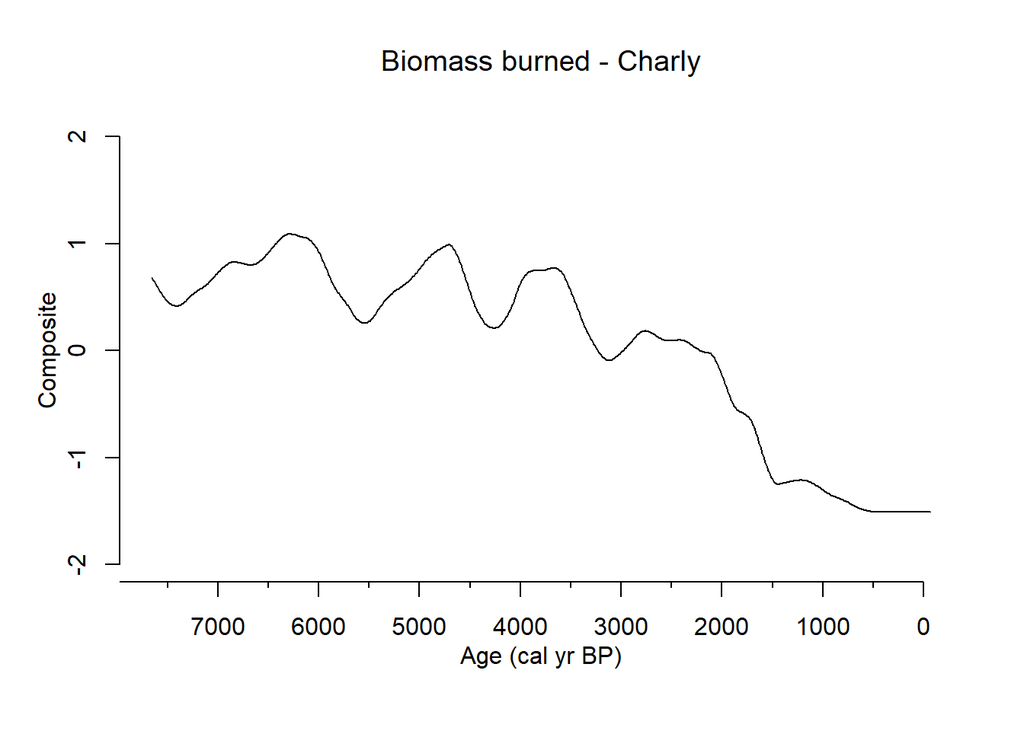

```r
plot(COMP2,ylim=c(-2,2),main=c("Biomass burned - Charly"))
```

```r
BBCharly<-as.data.frame(COMP2$Result[,1:5])
```

# *Pikku*

```r
Counts=c("Fire_histories/Count_Pikku.csv","Fire_histories/Count_Pikku.csv","Fire_histories/Count_Pikku.csv")
metadata=c("Fire_histories/metadata.csv")
mydata=pfAddData(files = Counts, metadata = metadata, type="CharAnalysis", sep = ";", dec = ".")
TR1=pfTransform(add=mydata, method=c("MinMax","Box-Cox","Z-Score"))
COMP2=pfCompositeLF(TR1, tarAge=seq(-70,9480,10), hw=500, nboot=100,  binhw=0.5)
```

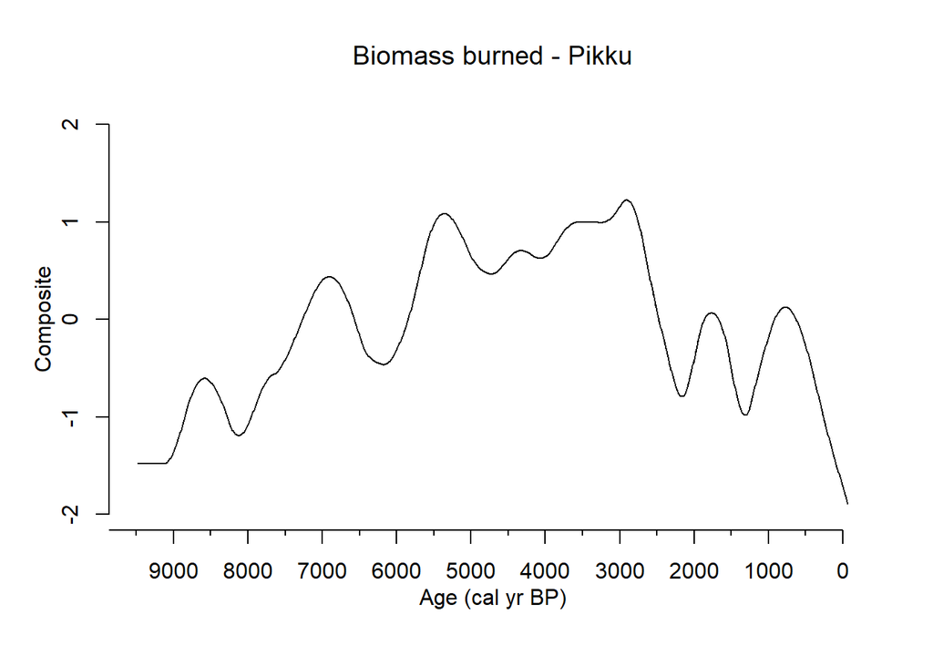

```r
plot(COMP2,ylim=c(-2,2),main=c("Biomass burned - Pikku"))
```

```r
BBPikku<-as.data.frame(COMP2$Result[,1:5])
#The output BBPikku is available as file "BBPikku.csv" in the folder "Fire_histories"
```

# *Rosalia*

```r
Counts=c("Fire_histories/Count_Rosalia.csv","Fire_histories/Count_Rosalia.csv","Fire_histories/Count_Rosalia.csv")
metadata=c("Fire_histories/metadata.csv")
mydata=pfAddData(files = Counts, metadata = metadata, type="CharAnalysis", sep = ";", dec = ".")
TR1=pfTransform(add=mydata, method=c("MinMax","Box-Cox","Z-Score"))
COMP2=pfCompositeLF(TR1, tarAge=seq(-70,11100,10), hw=500, nboot=100,  binhw=0.5)
```

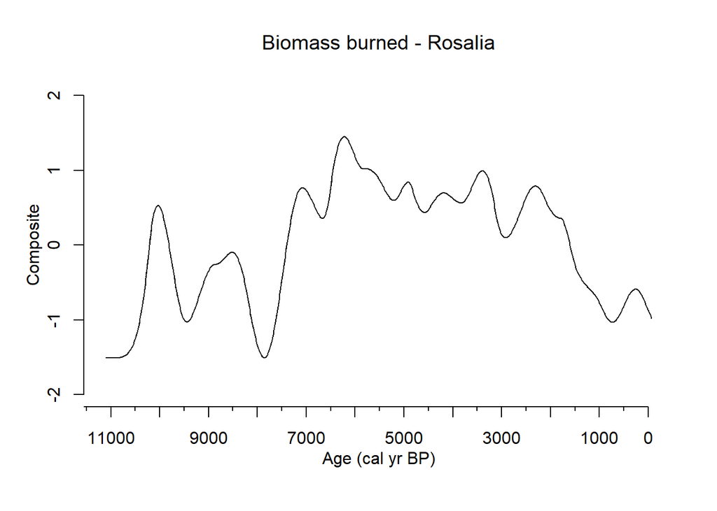

```r
plot(COMP2,ylim=c(-2,2),main=c("Biomass burned - Rosalia"))
```

```r
BBRosalia<-as.data.frame(COMP2$Result[,1:5])
#The output BBRosalia is available as file "BBRosalia.csv" in the folder "Fire_histories"
```

# *Regional*

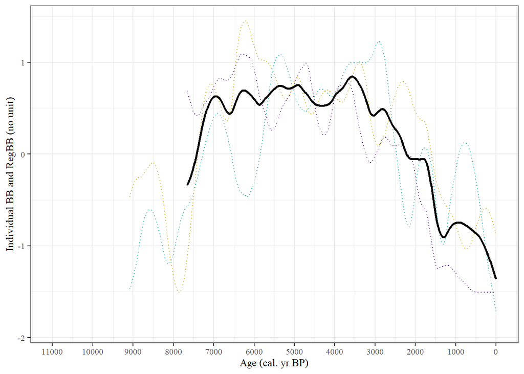

```r
BB_Charly<-BBCharly[,c(1,3)]
BB_Pikku<-BBPikku[,c(1,3)]
BB_Rosalia<-BBRosalia[,c(1,3)]
colnames(BB_Charly)<-c("Age","MeanCharly")
colnames(BB_Pikku)<-c("Age","MeanPikku")
colnames(BB_Rosalia)<-c("Age","MeanRosalia")

BB_Reg<-merge(BB_Rosalia,BB_Pikku,by=c("Age"),all.x = TRUE)
BB_Reg<-merge(BB_Reg,BB_Charly,by=c("Age"),all.x = TRUE)
BB_Reg[,5]<-apply(BB_Reg[,2:4],1,mean,na.rm=T)
colnames(BB_Reg)<-c("AGE","MEAN.of_boot.")
#The output BB_reg is available as file "BB_Reg.csv" in the folder "Fire_histories"


for (i in 1:nrow(BB_Reg)){
BB_Reg[i,6]<-quantile(BB_Reg[i,2:4], probs = c(0.05),na.rm=T)
BB_Reg[i,7]<-quantile(BB_Reg[i,2:4], probs = c(0.95),na.rm=T)
}

BB_Reg[775:nrow(BB_Reg),5:7]<-NA
BB_Reg[917:1118,2]<-NA
BB_Reg[918:1118,3]<-NA

colnames(BB_Reg)<-c("Age","Rosalia","Pikku","Charly","Mean","Low","High")
BB_Reg<-as.data.frame(BB_Reg)
BB_Reg$Age<-as.numeric(BB_Reg$Age)

RegBB_plot<-
ggplot(data=BB_Reg,aes(x=Age,y=Mean))+
   theme_bw()+
   scale_x_reverse(limits = c(11000,0), breaks = seq(0,11000,1000))+
   geom_line(aes(x=Age,y=Charly),color="darkorchid4",linetype = "dotted")+
   geom_line(aes(x=Age,y=Pikku),color="lightseagreen",linetype = "dotted")+
   geom_line(aes(x=Age,y=Rosalia),color="gold3",linetype = "dotted")+
   geom_line(size=1)+
   labs(x="Age (cal. yr BP)",y="Individual BB and RegBB (no unit)") +
   theme(text=element_text(family="Times",size=10))
RegBB_plot
```

## **Fire frequency reconstruction**

```r
dirs<-c('Fire_histories/')
Files<-list.files(dirs)
Lakesfires<-read.csv("Fire_histories/Fire_events.csv",h=T,sep=";")
```

# *Charly*

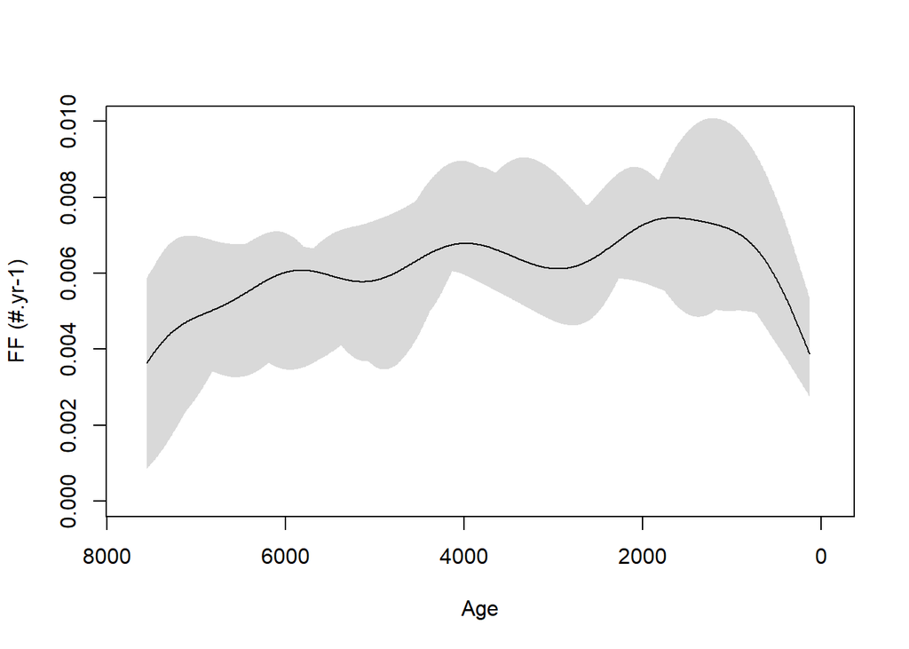

```r
Charlyfires<-Lakesfires[,3]
Charlyfires<-Charlyfires[!is.na(Charlyfires)]
fevent=c(Charlyfires)
ffCharly=kdffreq(fevent,up=-64,lo=7657,bandwidth = 500, nbboot=10,pseudo=FALSE)
mat_ffCharly<-matrix(cbind(ffCharly$age,ffCharly$ff),ncol=2)
plot.kdffreq(ffCharly,ylim=c(0,0.01),xlim=c(7700,-60),bty="n")
```

```r
colnames(mat_ffCharly)=c("Age","ff")
mat_ffCharly<-approx(mat_ffCharly[,1],mat_ffCharly[,2],method="linear",xout=seq(-70,11100,by=10))
```

# *Pikku*

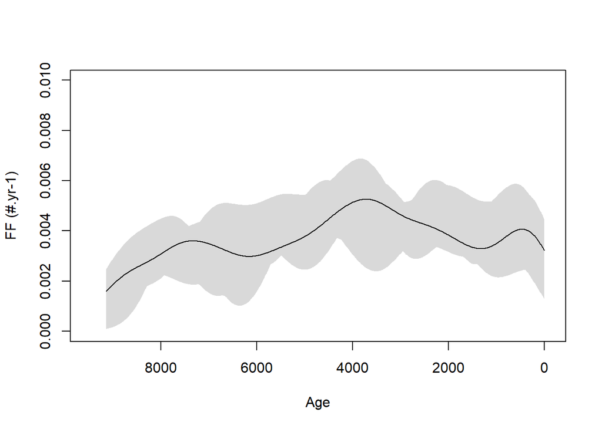

```r
Pikkufires<-Lakesfires[,2]
Pikkufires<-Pikkufires[!is.na(Pikkufires)]
fevent=c(Pikkufires)
ffPikku=kdffreq(fevent,up=-64,lo=9479,bandwidth = 500, nbboot=10,pseudo=FALSE)
mat_ffPikku<-matrix(cbind(ffPikku$age,ffPikku$ff),ncol=2)
plot.kdffreq(ffPikku,ylim=c(0,0.01),xlim=c(9500,-60),bty="n")
```

```r
colnames(mat_ffPikku)=c("Age","ff")
mat_ffPikku<-approx(mat_ffPikku[,1],mat_ffPikku[,2],method="linear",xout=seq(-70,11100,by=10))
```

# *Rosalia*

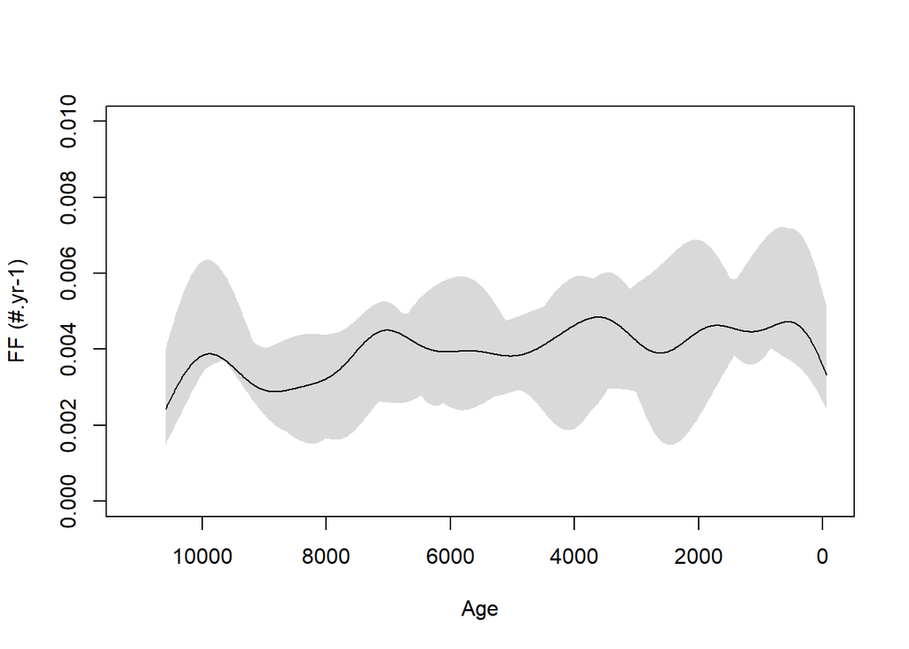

```r
Rosaliafires<-Lakesfires[,1]
Rosaliafires<-Rosaliafires[!is.na(Rosaliafires)]
fevent=c(Rosaliafires)
ffRosalia=kdffreq(fevent,up=-64,lo=11096,bandwidth = 500, nbboot=10,pseudo=FALSE)
mat_ffRosalia<-matrix(cbind(ffRosalia$age,ffRosalia$ff),ncol=2)
plot.kdffreq(ffRosalia,ylim=c(0,0.01),xlim=c(11100,-60),bty="n")
```

```r
colnames(mat_ffRosalia)=c("Age","ff")
mat_ffRosalia<-approx(mat_ffRosalia[,1],mat_ffRosalia[,2],method="linear",xout=seq(-70,11100,by=10))
```

# *Regional*

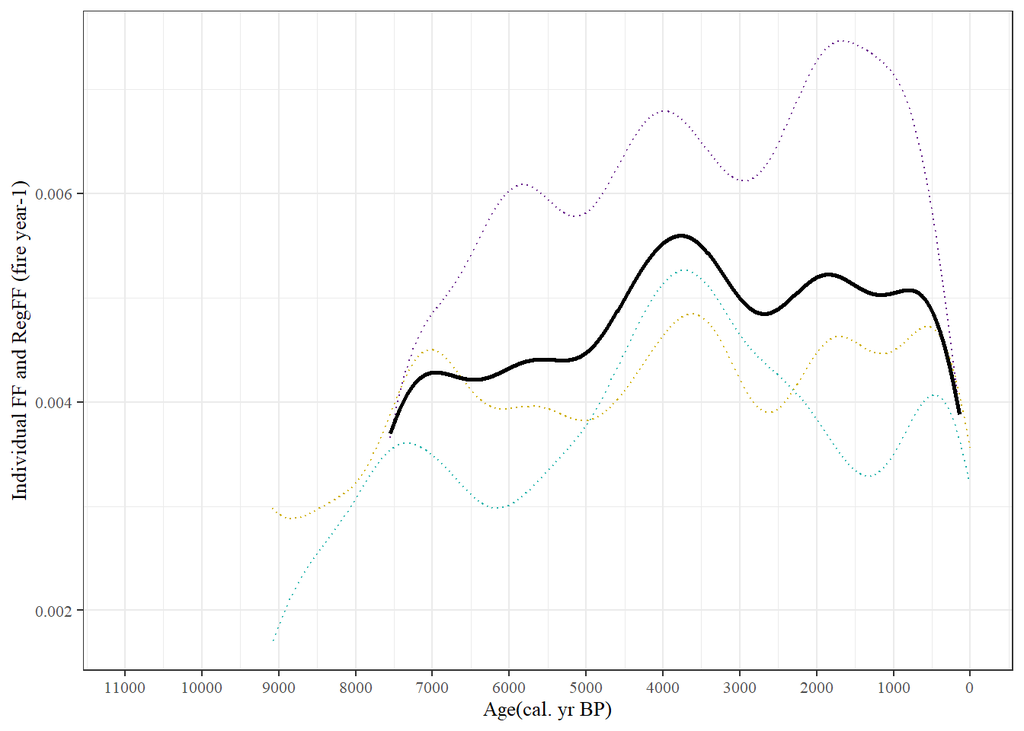

```r
FF<-cbind(mat_ffRosalia$x,mat_ffPikku$y,mat_ffCharly$y,mat_ffRosalia$y)
FF<-data.frame(FF)

FF[,5]<-apply(FF[,2:4],1,mean,na.rm=F)
colnames(FF)=c("Age","FFPikku","FFCharly","FFRosalia","FFmean")
FF$Age<-as.numeric(FF$Age)
Reg_FF<-FF
#The output Reg_FF is available as file "FF_Reg.csv" in the folder "Fire_histories"

for (i in 1:nrow(FF)){
FF[i,6]<-quantile(FF[i,2:4], probs = c(0.05),na.rm=T)
FF[i,7]<-quantile(FF[i,2:4], probs = c(0.95),na.rm=T)
}
FF[8:10,5:7]<-NA
FF[764:nrow(FF),5:7]<-NA
colnames(FF)<-c("Age","Pikku","Charly","Rosalia","Mean","Low","High")
FF[917:1118,2]<-NA
FF[918:1118,4]<-NA

RegFF_plot<-
ggplot(data=FF,aes(x=Age,y=Mean))+
   theme_bw()+
   scale_x_reverse(limits = c(11000,0), breaks = seq(0,11000,1000))+
   geom_line(aes(x=Age,y=Charly),color="darkorchid4",linetype = "dotted")+
   geom_line(aes(x=Age,y=Pikku),color="lightseagreen",linetype = "dotted")+
   geom_line(aes(x=Age,y=Rosalia),color="gold3",linetype = "dotted")+
   geom_line(size=1)+
   labs(x="Age(cal. yr BP)",y="Individual FF and RegFF (fire year-1)")+
   theme(text=element_text(family="Times",size=10))
RegFF_plot
```

## **Fire size reconstruction**

# *Rescaling of BB and RegBB*

```r
RegBB<-data.frame(BB_Reg[,1],BB_Reg[,5])
colnames(RegBB)<-c("Age","BBmean")
RegBBmax<-max(RegBB$BBmean,na.rm=T)
RegBBmin<-min(RegBB$BBmean,na.rm=T)

RegBB[,3]<-c((RegBB[,2]-RegBBmin)/(RegBBmax-RegBBmin))
colnames(RegBB)<-c("Age","BBmean","RegBBrescale")
RegBB[,4]<-RegBB$RegBBrescale+1
colnames(RegBB)<-c("Age","BBmean","RegBBrescale","RegBBb")

RegBB_Charly<-data.frame(BBCharly$AGE,BBCharly[,3])
colnames(RegBB_Charly)<-c("Age","BBmean")
RegBB_Charly[,3]<-c((RegBB_Charly[,2]-RegBBmin)/(RegBBmax-RegBBmin))
colnames(RegBB_Charly)<-c("Age","BBmean","RegBBrescale")
RegBB_Charly[,4]<-RegBB_Charly$RegBBrescale+1
colnames(RegBB_Charly)<-c("Age","BBmean","RegBBrescale","RegBBb")

RegBB_Pikku<-data.frame(BBPikku$AGE,BBPikku[,3])
colnames(RegBB_Pikku)<-c("Age","BBmean")
RegBB_Pikku[,3]<-c((RegBB_Pikku[,2]-RegBBmin)/(RegBBmax-RegBBmin))
colnames(RegBB_Pikku)<-c("Age","BBmean","RegBBrescale")
RegBB_Pikku[,4]<-RegBB_Pikku$RegBBrescale+1
colnames(RegBB_Pikku)<-c("Age","BBmean","RegBBrescale","RegBBb")

RegBB_Rosalia<-data.frame(BBRosalia$AGE,BBRosalia[,3])
colnames(RegBB_Rosalia)<-c("Age","BBmean")
RegBB_Rosalia[,3]<-c((RegBB_Rosalia[,2]-RegBBmin)/(RegBBmax-RegBBmin))
colnames(RegBB_Rosalia)<-c("Age","BBmean","RegBBrescale")
RegBB_Rosalia[,4]<-RegBB_Rosalia$RegBBrescale+1
colnames(RegBB_Rosalia)<-c("Age","BBmean","RegBBrescale","RegBBb")
```

# *Rescaling of FF and RegFF*

```r
RegFF<-data.frame(Reg_FF$Age,Reg_FF$FFmean)
colnames(RegFF)<-c("Age","FFmean")
RegFFmax<-max(RegFF$FFmean,na.rm=T)
RegFFmin<-min(RegFF$FFmean,na.rm=T)
RegFF[,3]<-c((RegFF[,2]-RegFFmin)/(RegFFmax-RegFFmin))
colnames(RegFF)<-c("Age","FFmean","RegFFrescale")
RegFF[,4]<-RegFF$RegFFrescale+1
colnames(RegFF)<-c("Age","FFmean","RegFFrescale","RegFFb")

RegFF_Charly<-data.frame(Reg_FF$Age,Reg_FF$FFCharly)
colnames(RegFF_Charly)<-c("Age","BBmean")
RegFF_Charly[,3]<-c((RegFF_Charly[,2]-RegFFmin)/(RegFFmax-RegFFmin))
colnames(RegFF_Charly)<-c("Age","BBmean","RegFFrescale")
RegFF_Charly[,4]<-RegFF_Charly$RegFFrescale+1
colnames(RegFF_Charly)<-c("Age","BBmean","RegFFrescale","RegFFb")

RegFF_Pikku<-data.frame(Reg_FF$Age,Reg_FF$FFPikku)
colnames(RegFF_Pikku)<-c("Age","BBmean")
RegFF_Pikku[,3]<-c((RegFF_Pikku[,2]-RegFFmin)/(RegFFmax-RegFFmin))
colnames(RegFF_Pikku)<-c("Age","BBmean","RegFFrescale")
RegFF_Pikku[,4]<-RegFF_Pikku$RegFFrescale+1
colnames(RegFF_Pikku)<-c("Age","BBmean","RegFFrescale","RegFFb")

RegFF_Rosalia<-data.frame(Reg_FF$Age,Reg_FF$FFRosalia)
colnames(RegFF_Rosalia)<-c("Age","BBmean")
RegFF_Rosalia[,3]<-c((RegFF_Rosalia[,2]-RegFFmin)/(RegFFmax-RegFFmin))
colnames(RegFF_Rosalia)<-c("Age","BBmean","RegFFrescale")
RegFF_Rosalia[,4]<-RegFF_Rosalia$RegFFrescale+1
colnames(RegFF_Rosalia)<-c("Age","BBmean","RegFFrescale","RegFFb")
```

# *FS index calculation*

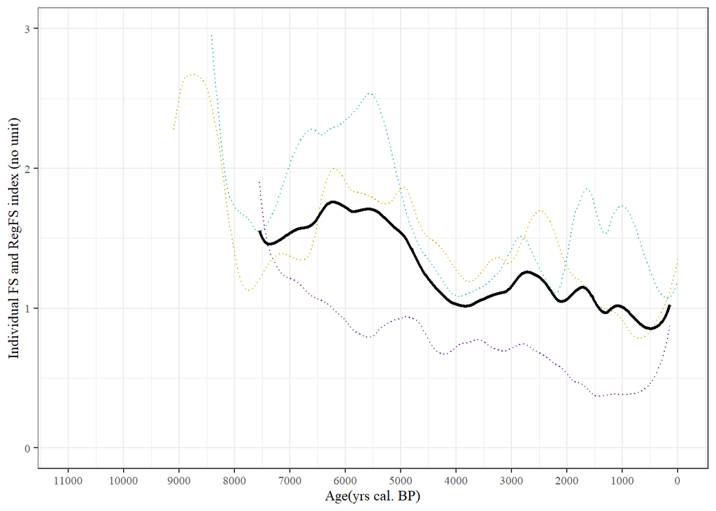

```r
FS<-merge(RegBB,RegFF,by="Age",all=T)
FS[,8]<-(FS$RegBBb/FS$RegFFb)
FSspline<-FS[,c(1,8)]

FS_Charly<-merge(RegBB_Charly,RegFF_Charly,by="Age",all=T)
FS_Charly[,8]<-(FS_Charly$RegBBb/FS_Charly$RegFFb)
FSspline_Charly<-FS_Charly[,c(1,8)]

FS_Pikku<-merge(RegBB_Pikku,RegFF_Pikku,by="Age",all=T)
FS_Pikku[,8]<-(FS_Pikku$RegBBb/FS_Pikku$RegFFb)
FSspline_Pikku<-FS_Pikku[,c(1,8)]

FS_Rosalia<-merge(RegBB_Rosalia,RegFF_Rosalia,by="Age",all=T)
FS_Rosalia[,8]<-(FS_Rosalia$RegBBb/FS_Rosalia$RegFFb)
FSspline_Rosalia<-FS_Rosalia[,c(1,8)]

FSspline<-merge(FSspline_Charly,FSspline_Rosalia,by=c("Age"),all=T)
FSspline<-merge(FSspline,FSspline_Pikku,by=c("Age"),all=T)
FS<-cbind(FSspline[,1],apply(FSspline[,2:4],1,mean,na.rm=F),FSspline[,2:4])

colnames(FS)<-c("Age","FSindex","FS_Charly","FS_Rosalia","FS_Pikku")
#The output FS is available as file "FS_Reg.csv" in the folder "Fire_histories"

FS$Age<-as.numeric(FS$Age)

for (i in 1:nrow(FS)){
FS[i,6]<-quantile(FS[i,3:5], probs = c(0.05),na.rm=T)
FS[i,7]<-quantile(FS[i,3:5], probs = c(0.95),na.rm=T)
}
FS[,2]<-apply(FS[,3:5],1,mean)
FS[c(1:21,765:nrow(FS)),c(2,6,7)]<-NA

colnames(FS)<-c("Age","Mean","Charly","Rosalia","Pikku","Low","High")
FS[917:1118,2]<-NA
FS[918:1118,4]<-NA

FS_plot<-
ggplot(data=FS,aes(x=Age,y=Mean))+
   theme_bw()+
   scale_x_reverse(limits = c(11000,0), breaks = seq(0,11000,1000))+
   geom_line(aes(x=Age,y=Charly),color="darkorchid4",linetype = "dotted")+
   geom_line(aes(x=Age,y=Pikku),color="lightseagreen",linetype = "dotted")+
   geom_line(aes(x=Age,y=Rosalia),color="gold3",linetype = "dotted")+
   geom_line(size=1)+
   ylim(0, 3)+
   labs(x="Age(yrs cal. BP)",y="Individual FS and RegFS index (no unit)")+
   theme(text=element_text(family="Times",size=10))
FS_plot
```